# Model_3_Naive_Bayes

```python
from google.colab import files

uploaded = files.upload()
```

Upload widget is only available when the cell has been executed in the current browser session. Please rerun this cell to enable.

```
Saving Sentiment_Data.csv to Sentiment_Data (1).csv
```

```python
from google.colab import files

uploaded = files.upload()
```

Upload widget is only available when the cell has been executed in the current browser session. Please rerun this cell to enable.

```
Saving slang.csv to slang (1).csv
```

### Load the libraries

```python
import numpy as np
import pandas as pd
import matplotlib.pyplot as plt
import seaborn as sns
from sklearn.model_selection import train_test_split, cross_val_score, KFold
from sklearn.metrics import confusion_matrix, f1_score, roc_auc_score, accuracy_score, roc_curve
from sklearn.feature_extraction.text import CountVectorizer
from sklearn.preprocessing import LabelEncoder
import re
```

```python
df = pd.read_csv('Sentiment_Data.csv', encoding='Latin1',nrows=20001)
df.dropna()
```

|  | Tweet | Sentiment |
| --- | --- | --- |
| 0 | @_angelica_toy Happy Anniversary!!!....The Day... | Mild_Pos |
| 1 | @McfarlaneGlenda Happy Anniversary!!!....The D... | Mild_Pos |
| 2 | @thevivafrei @JustinTrudeau Happy Anniversary!... | Mild_Pos |
| 3 | @NChartierET Happy Anniversary!!!....The Day t... | Mild_Pos |
| 4 | @tabithapeters05 Happy Anniversary!!!....The D... | Mild_Pos |
| ... | ... | ... |
| 19996 | @TrueNorthCentre Naturally uneducated fringe c... | Strong_Pos |
| 19997 | If you were a Freedom Convoy protestor, or aga... | Mild_Pos |
| 19998 | Ottawa police cut email access over fears info... | Mild_Neg |
| 19999 | Huge blow to PP and a signal he needs to move ... | Strong_Pos |
| 20000 | Were you a Freedom Convoy supporter (yes you w... | Strong_Pos |

20001 rows × 2 columns

### Data Cleaning

```python
# Reference- https://www.kaggle.com/datasets/gowrishankarp/chat-slang-abbreviations-acronyms
# handled slangs & abbreviations

dt = pd.read_csv('slang.csv', usecols=['acronym', 'expansion'])
pat = r'\b(?:' + '|'.join(map(re.escape, dt['acronym'])) + r')\b'
def slangs_exp(text):
    return re.sub(pat, lambda match: dt.loc[dt['acronym'] == match.group(0), 'expansion'].iloc[0], text)

df['Tweet'] = df['Tweet'].apply(slangs_exp)
```

```python
!pip install demoji
```

```python
# handled hashtags, mentions, whitespace, URLS, lowercase & emojis
import demoji
def cleaning(txt):
  txt = re.sub(r'http\S+|www\S+|https\S+', '', txt, flags=re.MULTILINE)
  txt = re.sub(r'@\w+', '', txt)
  txt = re.sub(r'#\w+', '', txt)
  txt = re.sub(r'\s+', '', txt).strip()
  txt = txt.lower()
  txt = demoji.replace(txt, '')
  return txt

df['Tweet'] = df['Tweet'].apply(cleaning)
```

```python
# handled negations

def negate(txt):
  words_negate = ['not','no',"n't",'don\'t','won\'t','can\'t']
  wrd = txt.split()
  for i,word in enumerate(wrd):
    if word.lower() in words_negate:
       if i + 1 < len(wrd):
        wrd[i] = "NEG_" + wrd[i+1]
        wrd[i + 1] = "NEG_" + wrd [i + 1]
  return ''.join(wrd)

df['Tweet'] = df['Tweet'].apply(negate)
```

```python
# lemmatization & tokenization

import nltk
from nltk.tokenize import word_tokenize
from nltk.corpus import wordnet
from nltk.stem import WordNetLemmatizer

nltk.download('punkt')
nltk.download('wordnet')
nltk.download('omw-1.4')
```

```
True
```

```python
def lem_tok(text):
    lemmatizer = WordNetLemmatizer()
    tokens = word_tokenize(text)
    lemmatized_tokens = [lemmatizer.lemmatize(token) for token in tokens]
    return lemmatized_tokens

df['Tweet'] = df['Tweet'].apply(lem_tok)
```

Sentiment Count

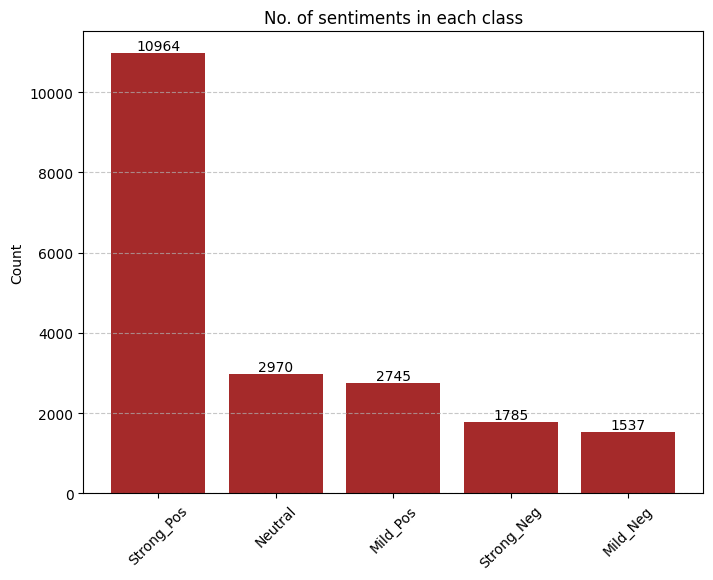

```python
count = df['Sentiment'].value_counts()

plt.figure(figsize=(8, 6))
no = plt.bar(count.index, count.values, color='brown')
plt.title('No. of sentiments in each class')
plt.ylabel('Count')
plt.xticks(rotation=45)
plt.grid(axis='y', linestyle='--', alpha=0.7)



for number in no:
    yval = number.get_height()
    plt.text(number.get_x() + number.get_width()/2, yval + 1, int(yval), ha='center', va='bottom')

plt.show()
```

### Model Building

```python
# Model Building

df['Tweet'] = df['Tweet'].astype(str)

from sklearn.feature_extraction.text import CountVectorizer
from sklearn.model_selection import train_test_split
from sklearn.naive_bayes import MultinomialNB
from sklearn.metrics import accuracy_score, classification_report, confusion_matrix, classification_report, roc_curve
import time

start_time = time.time()

# Convert text data into unigram + bigram
min_freq = 50
vector = CountVectorizer(ngram_range=(1, 2), binary=True)
X = vector.fit_transform(df['Tweet'])
y = df['Sentiment']

# Encode the target variable
label = LabelEncoder()
y = label.fit_transform(df['Sentiment'])

# train-test split
X_train, X_test, y_train, y_test = train_test_split(X, y, test_size=0.2, random_state=42)

naive_model = MultinomialNB(alpha=1)
naive_model.fit(X_train, y_train)
y_pred = naive_model.predict(X_test)
y_pred_proba = naive_model.predict_proba(X_test)

cv_scores = cross_val_score(naive_model, X, y, cv=5)  # cv=5 for 5-fold cross-validation

# Output the cross-validation scores
print("Cross-Validation Scores:", cv_scores)
print("Mean CV Accuracy:", cv_scores.mean())

end = time.time() - start_time

#accuracy
train_acc = accuracy_score(y_train, naive_model.predict(X_train))
test_acc = accuracy_score(y_test, y_pred)

print(f"\nTime taken for model training: {end:.2f} seconds")
print("\nTraining Accuracy:", train_acc)
print("\nTesting Accuracy:", test_acc)
```

```
Cross-Validation Scores: [0.41114721 0.44       0.40025    0.41175    0.414     ]
Mean CV Accuracy: 0.4154294426393402

Time taken for model training: 2.93 seconds

Training Accuracy: 0.9103125

Testing Accuracy: 0.4443889027743064
```

Here we can see that there is a huge difference between accuracy of training & test data which is leading to overfitting, we can tune the model by increasing value of smoothing co-efficient alpha = 10 to reduce the overfitting

#### Model Tuning

```python
df['Tweet'] = df['Tweet'].astype(str)

from sklearn.feature_extraction.text import CountVectorizer
from sklearn.model_selection import train_test_split
from sklearn.naive_bayes import MultinomialNB
from sklearn.metrics import accuracy_score, classification_report, confusion_matrix, classification_report, roc_curve
import time

start_time = time.time()

# Convert text data into unigram + bigram
min_freq = 50
vector = CountVectorizer(ngram_range=(1, 2), binary=True)
X = vector.fit_transform(df['Tweet'])
y = df['Sentiment']

# Encode the target variable
label = LabelEncoder()
y = label.fit_transform(df['Sentiment'])

# train-test split
X_train, X_test, y_train, y_test = train_test_split(X, y, test_size=0.2, random_state=42)

naive_model = MultinomialNB(alpha=10)
naive_model.fit(X_train, y_train)
y_pred = naive_model.predict(X_test)
y_pred_proba = naive_model.predict_proba(X_test)

cv_scores = cross_val_score(naive_model, X, y, cv=5)  # cv=5 for 5-fold cross-validation

# Output the cross-validation scores
print("Cross-Validation Scores:", cv_scores)
print("Mean CV Accuracy:", cv_scores.mean())

end = time.time() - start_time

#accuracy
train_acc = accuracy_score(y_train, naive_model.predict(X_train))
test_acc = accuracy_score(y_test, y_pred)

#AUC
y_train_pred_proba = naive_model.predict_proba(X_train)
train_auc = roc_auc_score(y_train, y_train_pred_proba, average='weighted', multi_class='ovr')
test_auc = roc_auc_score(y_test, y_pred_proba, average='weighted', multi_class='ovr')

#confusion matrix
train_matrix = confusion_matrix(y_train, naive_model.predict(X_train))
test_matrix = confusion_matrix(y_test, y_pred)

print(f"\nTime taken for model training: {end:.2f} seconds")
print("\nTraining Accuracy:", train_acc)
print("Testing Accuracy:", test_acc)
print("\nTraining AUC score:", train_auc)
print("Testing AUC score:", test_auc)
print("\nTraining Confusion Matrix:")
print(train_matrix)
print("\nTesting Confusion Matrix:")
print(test_matrix)
```

```
Cross-Validation Scores: [0.5516121 0.5655    0.557     0.56375   0.57     ]
Mean CV Accuracy: 0.5615724193951512

Time taken for model training: 2.70 seconds

Training Accuracy: 0.6075
Testing Accuracy: 0.5703574106473381

Training AUC score: 0.7383796142977022
Testing AUC score: 0.5718718861987306

Training Confusion Matrix:
[[ 246    1   21    0  969]
 [   9  207   43    0 1926]
 [   5    1  389    0 2008]
 [   9    1   29  111 1239]
 [   7    0   12    0 8767]]

Testing Confusion Matrix:
[[  45    2   10    0  243]
 [   3   13   18    0  526]
 [   3    0   51    0  513]
 [   6    0   10    2  378]
 [   0    1    6    0 2171]]
```

### Here we can see that after changing value of alpha to 10, problem of overfitting is solved, but the model is underfitting. To solve given problem, we can use boostimg or bagging models.

```
Cross-Validation Scores: [0.5516121 0.5655    0.557     0.56375   0.57     ]
Mean CV Accuracy: 0.5615724193951512

Time taken for model training: 2.41 seconds

Training Accuracy: 0.6037142857142858
Testing Accuracy: 0.5714047658723546

Training AUC score: 0.7370196251873858
Testing AUC score: 0.5681235914642072
```

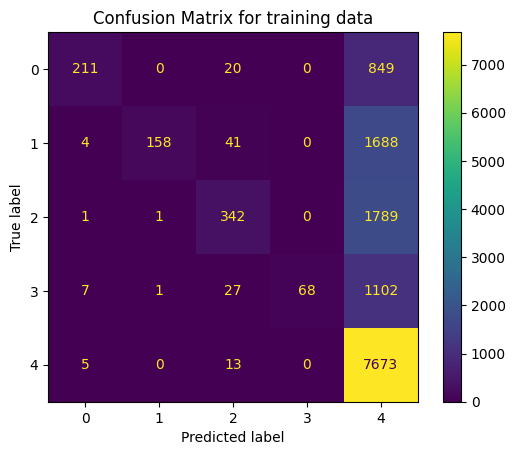

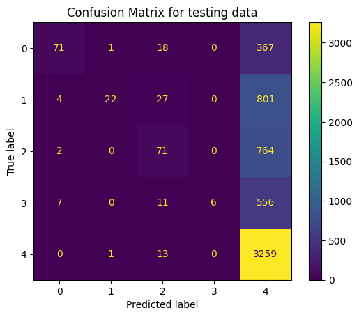

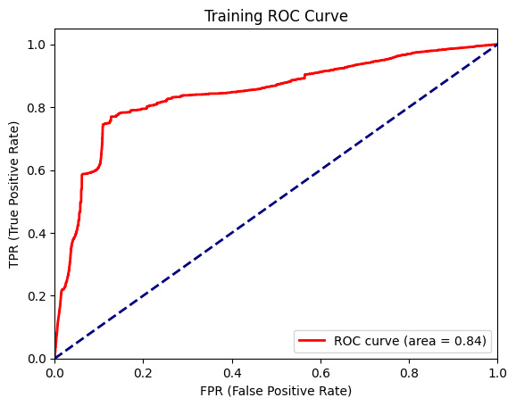

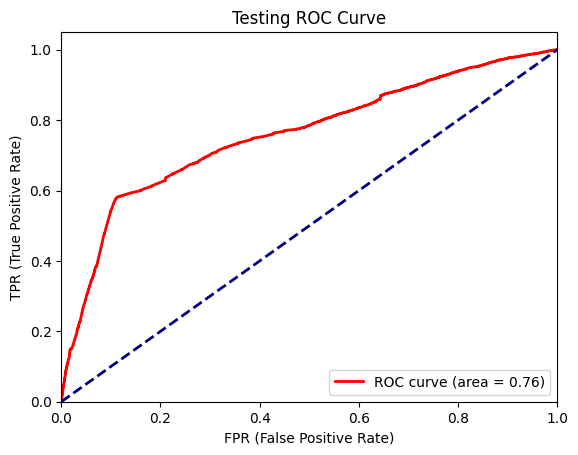

```python
df['Tweet'] = df['Tweet'].astype(str)

from sklearn.feature_extraction.text import CountVectorizer
from sklearn.model_selection import train_test_split
from sklearn.naive_bayes import MultinomialNB
from sklearn.metrics import accuracy_score, classification_report, confusion_matrix, classification_report, roc_curve
import time

start_time = time.time()

# Convert text data into unigram + bigram
min_freq = 50
vector = CountVectorizer(ngram_range=(1, 2), binary=True)
X = vector.fit_transform(df['Tweet'])
y = df['Sentiment']

# Encode the target variable
label = LabelEncoder()
y = label.fit_transform(df['Sentiment'])

# train-test split
X_train, X_test, y_train, y_test = train_test_split(X, y, test_size=0.3, random_state=42)

naive_model = MultinomialNB(alpha=10)
naive_model.fit(X_train, y_train)
y_pred = naive_model.predict(X_test)
y_pred_proba = naive_model.predict_proba(X_test)

# cross validatiom
cv_scores = cross_val_score(naive_model, X, y, cv=5)

# Output the cross-validation scores
print("Cross-Validation Scores:", cv_scores)
print("Mean CV Accuracy:", cv_scores.mean())

end = time.time() - start_time

#accuracy
train_acc = accuracy_score(y_train, naive_model.predict(X_train))
test_acc = accuracy_score(y_test, y_pred)

#AUC
y_train_pred_proba = naive_model.predict_proba(X_train)
train_auc = roc_auc_score(y_train, y_train_pred_proba, average='weighted', multi_class='ovr')
test_auc = roc_auc_score(y_test, y_pred_proba, average='weighted', multi_class='ovr')

print(f"\nTime taken for model training: {end:.2f} seconds")
print("\nTraining Accuracy:", train_acc)
print("Testing Accuracy:", test_acc)

print("\nTraining AUC score:", train_auc)
print("Testing AUC score:", test_auc)

import matplotlib.pyplot as plt
from sklearn.metrics import roc_curve, auc
from sklearn.preprocessing import label_binarize
from sklearn.metrics import ConfusionMatrixDisplay
import numpy as np


n_classes = len(np.unique(y))
train_binary = label_binarize(y_train, classes=np.arange(n_classes))
test_binary = label_binarize(y_test, classes=np.arange(n_classes))

# Confusion Matrix
def plot_conf_matrix(y_true, y_pred, title):
    dsy = ConfusionMatrixDisplay.from_predictions(y_true, y_pred)
    dsy.ax_.set_title(title)
    plt.show()

# ROC curve
def plot_roc_curve(y_true, y_proba, title):

    fpr, tpr, _ = roc_curve(y_true.ravel(), y_proba.ravel())
    roc_area = auc(fpr, tpr)


    plt.figure()
    plt.plot(fpr, tpr, color='red', lw=2, label='ROC curve (area = %0.2f)' % roc_area)
    plt.plot([0, 1], [0, 1], color='navy', lw=2, linestyle='--')
    plt.xlim([0.0, 1.0])
    plt.ylim([0.0, 1.05])
    plt.xlabel('FPR (False Positive Rate)')
    plt.ylabel('TPR (True Positive Rate)')
    plt.title(title)
    plt.legend(loc="lower right")
    plt.show()

y_train_pred = naive_model.predict(X_train)
y_train_proba = naive_model.predict_proba(X_train)


y_test_pred = naive_model.predict(X_test)
y_test_proba = naive_model.predict_proba(X_test)

# Draw confusion matrix
plot_conf_matrix(y_train, y_train_pred, "Confusion Matrix for training data")
plot_conf_matrix(y_test, y_test_pred, "Confusion Matrix for testing data")

# Draw ROC curve
plot_roc_curve(train_binary, y_train_proba, "Training ROC Curve")
plot_roc_curve(test_binary, y_test_proba, "Testing ROC Curve")
```

## Next Steps

When it comes to small dataset, the model is always overfitting, so another better option is to increase the size of dataset to solve problems.

For that, we can use google colab GPU or kaggle GPU

## Conclusion

As the dataset was very large containing 4,00,000 rows, we were out of runtime. So we tried the models on few data points but that is leading to overfitting or underfitting in the data.